icfes: competencia: - formulacion_ejecucion nivel_dificultad: 3 contenido: categoria: geometria tipo: no_generico contexto: matematico eje_axial: eje2 componente: geometrico_metrico

```r
options(OutDec = ".")  # Asegurar punto decimal en este chunk

# Establecer semilla aleatoria
set.seed(sample(1:10000, 1))

# Aleatorizamos los nombres para contextualizar el problema
nombres <- c("Camilo", "Andrés", "Sofía", "Manuel", "Laura", "Carlos",
             "Daniela", "Miguel", "Valentina", "Eduardo", "Natalia",
             "José", "Isabella", "Gabriel", "Mariana", "Santiago", "Lucía",
             "Alejandro", "Catalina", "Mateo", "Valeria", "Sebastián", "Juliana")
nombre <- sample(nombres, 1)

# Aleatorizamos los tipos de recipientes
recipientes <- c("cilindro", "tubo", "conducto", "tanque cilíndrico",
                 "recipiente cilíndrico", "contenedor cilíndrico",
                 "ducto cilíndrico", "depósito cilíndrico", "cañería cilíndrica")
recipiente <- sample(recipientes, 1)

# Aleatorizar adjetivos para el cilindro interno
adjetivos_interno <- c("interno", "hueco", "vacío", "interior", "central", "medio")
adjetivo_interno <- sample(adjetivos_interno, 1)

# Aleatorizar líquidos
liquidos <- c("aceite", "combustible", "líquido", "fluido", "agua", "refrigerante",
              "solución", "mezcla", "sustancia")
liquido <- sample(liquidos, 1)

# Aleatorizar lo que se desea calcular
calculos <- c("la cantidad de", "el volumen de", "cuánto", "qué cantidad de",
              "cuántos litros de", "qué volumen de", "la capacidad de")
calculo <- sample(calculos, 1)

# Aleatorizar verbos para la acción
verbos <- c("llenar", "contener", "almacenar", "ocupar", "requerir")
verbo <- sample(verbos, 1)

# Aleatorizar medidas del cilindro (manteniendo consistencia matemática)
# Primero generamos el radio interno (entre 0.1 y 0.4 metros)
r_int <- round(runif(1, 0.1, 0.4), 2)

# Luego generamos el radio externo, asegurando que sea mayor que el interno
# Radio externo entre 1.5 y 2.5 veces el radio interno
factor_radio <- runif(1, 1.5, 2.5)
r_ext <- round(r_int * factor_radio, 2)

# Calculamos el diámetro externo (exactamente 2 veces el radio externo)
d_ext <- 2 * r_ext

# Altura del cilindro (entre 0.5 y 4 metros)
altura <- round(runif(1, 0.5, 4), 2)

# Calcular el grosor de la pared del cilindro
grosor <- r_ext - r_int

# Verificar coherencia física
if (grosor < 0.05) {
  # Asegurar un grosor mínimo de 0.05 unidades
  grosor <- round(runif(1, 0.05, 0.2), 2)
  r_ext <- r_int + grosor
  # Asegurar que el diámetro externo sea exactamente 2 veces el radio externo
  d_ext <- 2 * r_ext
}

# Calcular el volumen necesario (es el volumen del cilindro interior)
volumen <- round(pi * (r_int^2) * altura, 2)

# Aleatorizar unidades de medida
unidades_longitud <- c("m", "cm", "dm")
unidad <- sample(unidades_longitud, 1)

# Ajustar valores según la unidad
factor_conversion <- 1
if (unidad == "cm") {
  factor_conversion <- 100
  d_ext <- d_ext * factor_conversion
  r_int <- r_int * factor_conversion
  altura <- altura * factor_conversion
  volumen <- volumen * (factor_conversion^3)
  r_ext <- r_ext * factor_conversion
} else if (unidad == "dm") {
  factor_conversion <- 10
  d_ext <- d_ext * factor_conversion
  r_int <- r_int * factor_conversion
  altura <- altura * factor_conversion
  volumen <- volumen * (factor_conversion^3)
  r_ext <- r_ext * factor_conversion
}

# Redondear todos los valores para mayor claridad
d_ext <- round(d_ext, 1)
r_int <- round(r_int, 1)
altura <- round(altura, 1)
r_ext <- round(r_ext, 1)
volumen <- round(volumen, 1)

# La respuesta correcta es "C) Altura del cilindro"
# Ya que para calcular el volumen necesitaríamos conocer la altura
opcion_correcta <- 3 # Índice de "Altura del cilindro" en el vector de opciones

# Vector de solución para r-exams (1 para la correcta, 0 para las incorrectas)
solucion <- c(0, 0, 1, 0)
```

```r
options(OutDec = ".")  # Asegurar punto decimal en este chunk

# Crear una función para dibujar el cilindro hueco usando R base
dibujar_cilindro_hueco <- function(r_int, r_ext, altura, unidad) {
  # Configurar el gráfico
  par(mar = c(2, 2, 2, 2))
  plot(0, 0, type = "n", xlim = c(-r_ext*1.5, r_ext*1.5), ylim = c(-r_ext*0.5, altura*1.2),
       xlab = "", ylab = "", axes = FALSE)

  # Factor de compresión para la perspectiva
  factor_compresion <- 0.4

  # Dibujar el cilindro externo
  # Base inferior (parte trasera - línea punteada)
  theta <- seq(0, pi, length.out = 100)
  x_ext_inf_tras <- r_ext * cos(theta)
  y_ext_inf_tras <- r_ext * factor_compresion * sin(theta)
  lines(x_ext_inf_tras, y_ext_inf_tras, lty = 2)

  # Base inferior (parte delantera - línea sólida)
  theta <- seq(pi, 2*pi, length.out = 100)
  x_ext_inf_del <- r_ext * cos(theta)
  y_ext_inf_del <- r_ext * factor_compresion * sin(theta)
  lines(x_ext_inf_del, y_ext_inf_del)

  # Base superior (elipse completa)
  theta <- seq(0, 2*pi, length.out = 200)
  x_ext_sup <- r_ext * cos(theta)
  y_ext_sup <- altura + r_ext * factor_compresion * sin(theta)
  lines(x_ext_sup, y_ext_sup)

  # Laterales externos
  lines(c(-r_ext, -r_ext), c(0, altura))
  lines(c(r_ext, r_ext), c(0, altura))

  # Dibujar el cilindro interno
  # Base inferior interna (parte trasera - línea punteada)
  theta <- seq(0, pi, length.out = 100)
  x_int_inf_tras <- r_int * cos(theta)
  y_int_inf_tras <- r_int * factor_compresion * sin(theta)
  lines(x_int_inf_tras, y_int_inf_tras, lty = 2)

  # Base inferior interna (parte delantera - línea sólida)
  theta <- seq(pi, 2*pi, length.out = 100)
  x_int_inf_del <- r_int * cos(theta)
  y_int_inf_del <- r_int * factor_compresion * sin(theta)
  lines(x_int_inf_del, y_int_inf_del)

  # Base superior interna (elipse completa)
  theta <- seq(0, 2*pi, length.out = 200)
  x_int_sup <- r_int * cos(theta)
  y_int_sup <- altura + r_int * factor_compresion * sin(theta)
  lines(x_int_sup, y_int_sup)

  # Laterales internos (líneas punteadas)
  lines(c(-r_int, -r_int), c(0, altura), lty = 2)
  lines(c(r_int, r_int), c(0, altura), lty = 2)

  # Añadir etiquetas y medidas
  # Altura
  arrows(r_ext + r_ext*0.2, 0, r_ext + r_ext*0.2, altura, code = 3, length = 0.1)
  text(r_ext + r_ext*0.4, altura/2, "Altura", pos = 4)

  # Radio interno
  arrows(0, altura, r_int, altura, code = 2, length = 0.1)
  text(r_int/2, altura + r_ext*0.2, paste("Radio interno =", r_int, unidad))

  # Radio externo
  arrows(0, 0, r_ext, 0, code = 2, length = 0.1)
  text(r_ext/2, -r_ext*0.2, paste("Radio externo =", r_ext, unidad))

  # Diámetro externo
  arrows(-r_ext, altura + r_ext*0.5, r_ext, altura + r_ext*0.5, code = 3, length = 0.1)
  text(0, altura + r_ext*0.7, paste("Diámetro externo =", 2*r_ext, unidad))

  # Grosor
  arrows(-r_ext, altura/2, -r_int, altura/2, code = 3, length = 0.1)
  text(-r_ext - r_ext*0.2, altura/2, paste("Grosor =", r_ext - r_int, unidad), pos = 2)
}

# Guardar la imagen del cilindro hueco
png("cilindro_hueco.png", width = 800, height = 800, res = 120)
dibujar_cilindro_hueco(r_int, r_ext, altura, unidad)
dev.off()
```

# Question

Santiago desea saber cuánto(a) refrigerante se necesita para llenar un cilindro interno, pero solamente cuenta con las medidas de las dimensiones que muestra la figura.

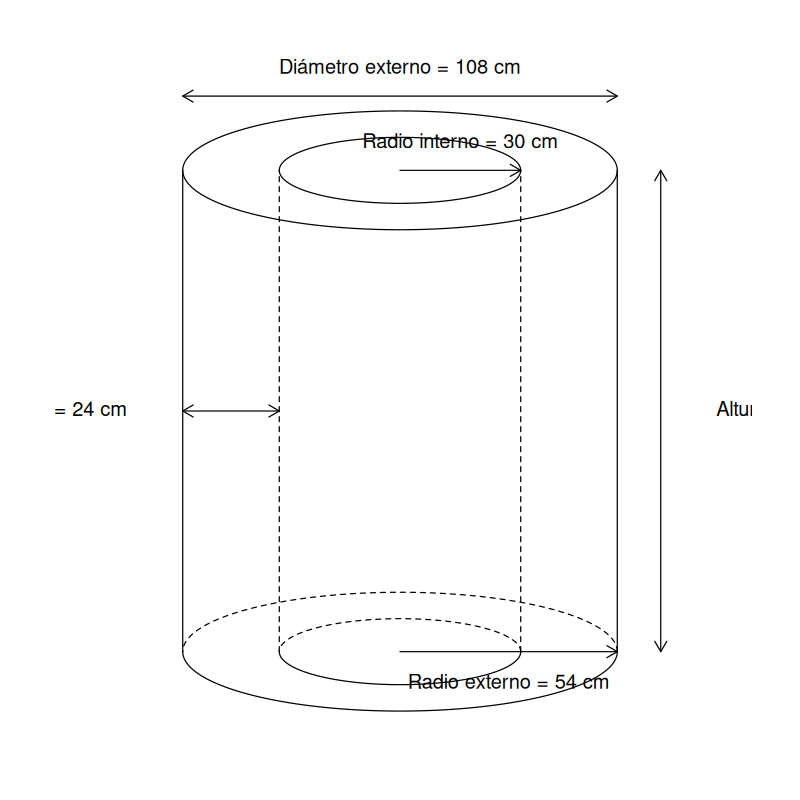

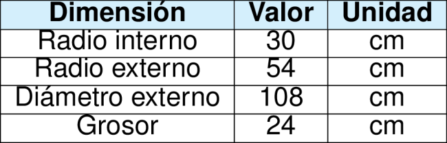

¿Cuál medida le falta a Santiago para hallar la cantidad deseada?

## Answerlist

- Radio externo.
- Diámetro externo.
- Altura del cilindro.
- Perímetro del cilindro.

# Solution

La respuesta correcta es: **Altura del cilindro**.

Para calcular el volumen de refrigerante necesario para llenar el cilindro interior, necesitamos calcular el volumen de un cilindro, cuya fórmula es:

$V = \pi \cdot r^2 \cdot h$

Donde: - $r$ es el radio (en este caso, el radio interno = 30 cm) - $h$ es la altura del cilindro

En el problema se nos proporciona: - Diámetro externo = 108 cm - Radio interno = 30 cm

Sin embargo, no se nos proporciona la altura del cilindro, que es esencial para calcular el volumen. Por lo tanto, a Santiago le falta conocer la altura del cilindro para poder calcular la cantidad de refrigerante necesaria.

Si tuviéramos la altura, el volumen se calcularía así: $V = \pi \cdot (30)^2 \cdot h = 2827.43 \cdot h$ cm³

## Answerlist

- Falso
- Falso
- Verdadero
- Falso

# Meta-information

exname: volumen_cilindro_hueco extype: schoice exsolution: 0010 exshuffle: TRUE exsection: Geometría|Volumen|Cilindro